# UCCS Project

## Load data

```r
nssa <- read.csv("NSSA.csv")
```

## Creating a composite HIT score

The Annenberg Institute evaluates whether programs maximize their service through “high-impact tutoring” using the following characteristics (Robinson, Kraft, Loeb, & Schueler, 2021):

1. Frequency (3 or more sessions per week)
2. Group size (1-4 students per session)
3. Personnel (ongoing support and training)
4. Alignment (high-quality materials coordinated with school curriculum)
5. Scheduling (during the school day)
6. Measurement (ongoing, informal, formative assessments)
7. Relationships (maintaining consistent tutors over time)
8. Prioritization (programs that target all students reduce stigma)

They also state that both in-person and online delivery can be effective, and that current research shows positive effects for early reading interventions and secondary math interventions. I do not include these criteria in the evaluation because they are ambiguous.

No data is currently available for personnel, alignment, measurement, relationships, or prioritization. The sum of the preceding variables will serve as a crude composite.

SPARK Early Literacy explicitly addresses prioritization. City Year’s AmeriCorps addresses alignment and relationships. TutorChat addresses relationships. Masteryhour.org addresses personnel. eTutorWorld addresses personnel. EdLight addresses alignment. Some programs hint at some characteristics of HIT but do not specify exactly what they mean.

Some organizations seem to not involve tutors at all, but are AI-powered edtech products. One listing is for an individual tutor.

```r
# ifelse(str_detect(ratio, "4:1|1:4|3:1|1:3|2:1|1:2|1:1|1:01"), 1, 0)
# "(\\d{1,2}):(\\d{1,2})"
# "\\1/\\2"

nssa2 <- nssa2 %>%
  mutate(setting = as.double(as.character(factor(setting, unique(setting), c(0,.5,1, NA)))),
         ratio = ifelse(str_detect(ratio, "5:1|[Ss]mall group|6:01|8:1|1:5|20:1"), 0, 1),
         freq = ifelse(freq >= 3, 1, 0),
         )

temp <- c("setting", "ratio", "freq")

nssa2$comp <- rowSums(nssa2[temp], na.rm = TRUE)

nssa2$wtcomp <- nssa2 %>%
  mutate(freq = 2 * freq) %>%
  select(temp) %>%
  rowSums(na.rm = TRUE)
```

```
## Note: Using an external vector in selections is ambiguous.
## i Use `all_of(temp)` instead of `temp` to silence this message.
## i See <https://tidyselect.r-lib.org/reference/faq-external-vector.html>.
```

## Creating a composite “eval” score

```r
nssa2$eval <- nssa2 %>%
  select(qed, rct) %>%
  rowSums(na.rm = TRUE)

nssa2 <- nssa2 %>%
  mutate(eval = factor(eval, levels = c(0, 1, 2), labels = c(0, 1, 1)))
```

## Exploring relationships

[figure not shown]

```r
ggplot(nssa, aes(cost_student))
```

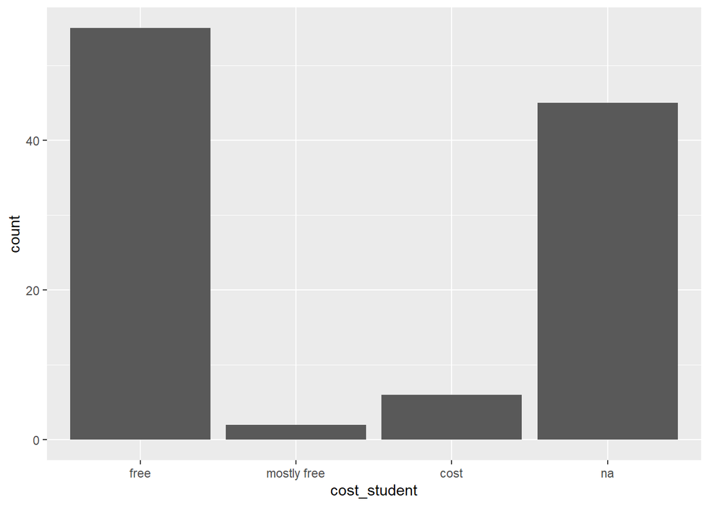

```r
nssa2 %>%
  group_by(cost_student) %>%
  ggplot(aes(cost_student)) +
  geom_bar()
```

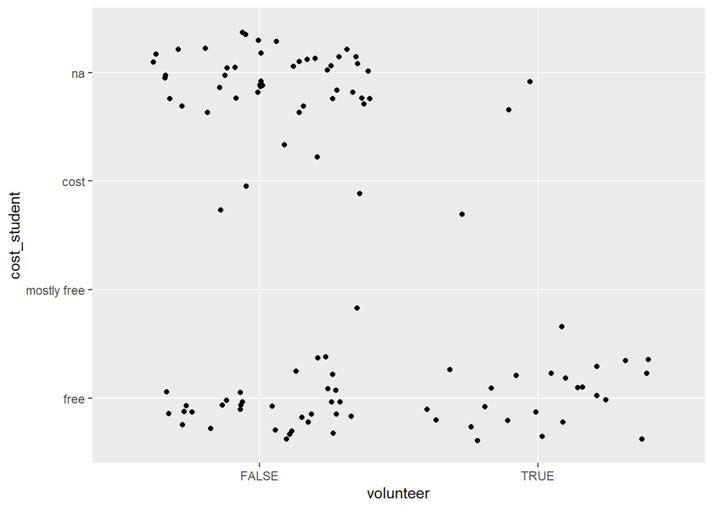

```r
nssa2 %>%
  mutate(volunteer = str_detect(tutor, "[Vv]olunteer")) %>%
  ggplot(aes(volunteer, cost_student)) +
  geom_jitter()
```

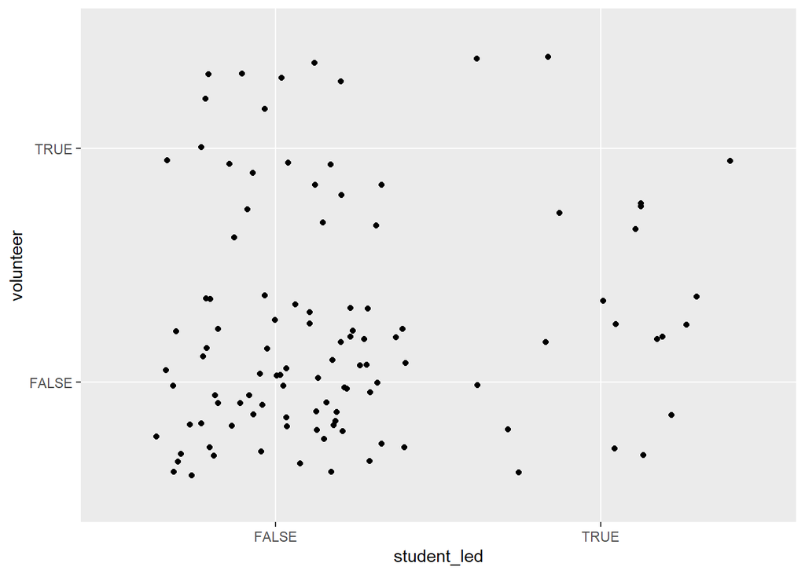

```r
student_led <- c("student-led", "student-run", "undergraduate", "college", "young adults")
nssa2 %>%
  mutate(student_led = str_detect(description, paste(student_led, collapse = "|"))) %>%
  mutate(volunteer = str_detect(tutor, "[Vv]olunteer")) %>%
  ggplot(aes(student_led, volunteer)) +
  geom_jitter()
```

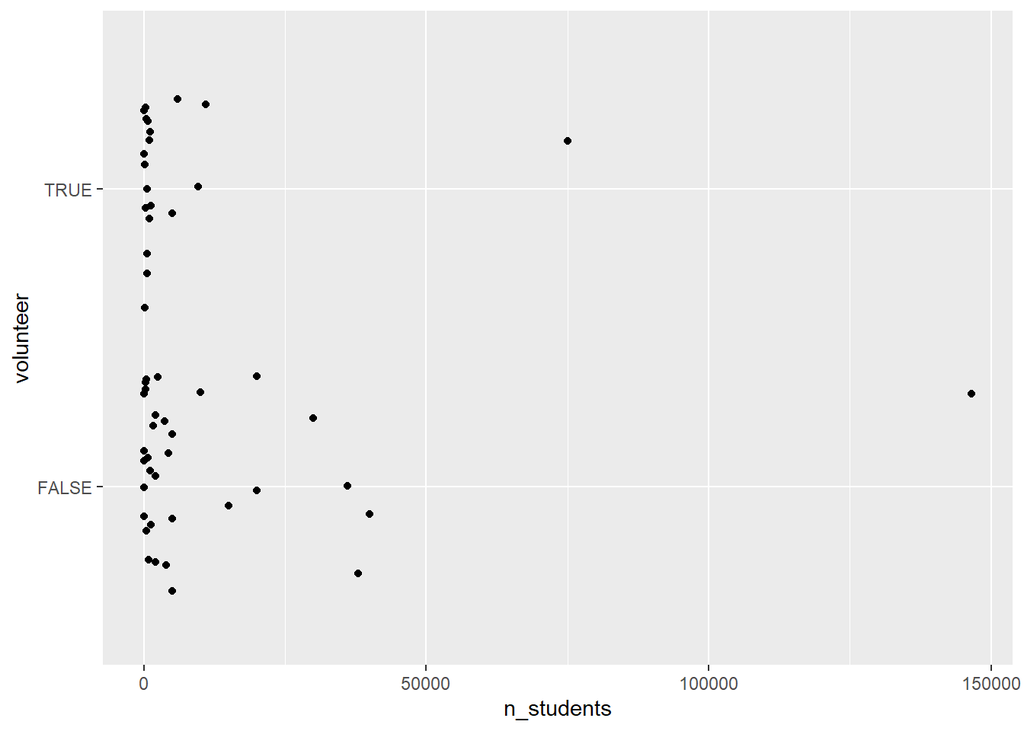

```r
nssa2 %>%
  mutate(volunteer = str_detect(tutor, "[Vv]olunteer")) %>%
  filter(!is.na(n_students)) %>%
  filter(n_students < 500000) %>%
  ggplot(aes(n_students, volunteer)) +
  geom_jitter()
```

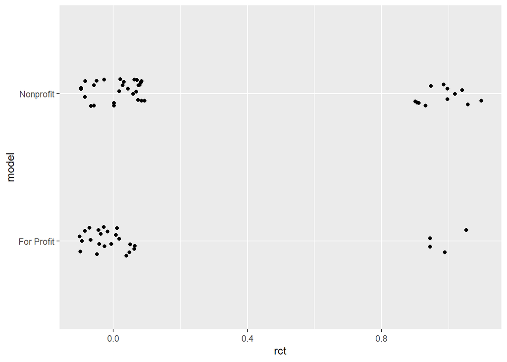

```r
# RCT versus profit model
nssa2 %>%
  filter(rct != "") %>%
  filter(model != "") %>%
  ggplot(aes(rct, model)) +
  geom_jitter(width = 0.1, height = 0.1)
```

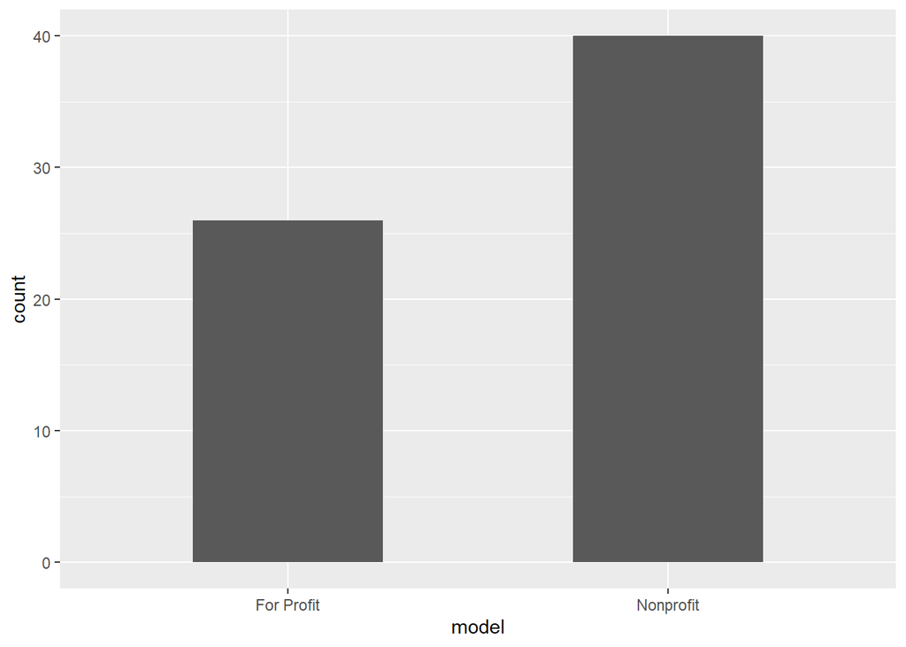

```r
nssa2 %>%
  filter(rct != "") %>%
  filter(model != "") %>%
  ggplot(aes(model)) +
  geom_bar(aes(fill = rct), position = "dodge", width = 0.5)
```

## Quantitative analysis

How many programs meet how many HIT criteria?

[Clustered bar chart](https://stackoverflow.com/questions/22305023/how-to-get-a-barplot-with-several-variables-side-by-side-grouped-by-a-factor) from Stack Overflow.

[Label wrapping](https://stackoverflow.com/questions/21878974/wrap-long-axis-labels-via-labeller-label-wrap-in-ggplot2) from Stack Overflow.

The final graph:

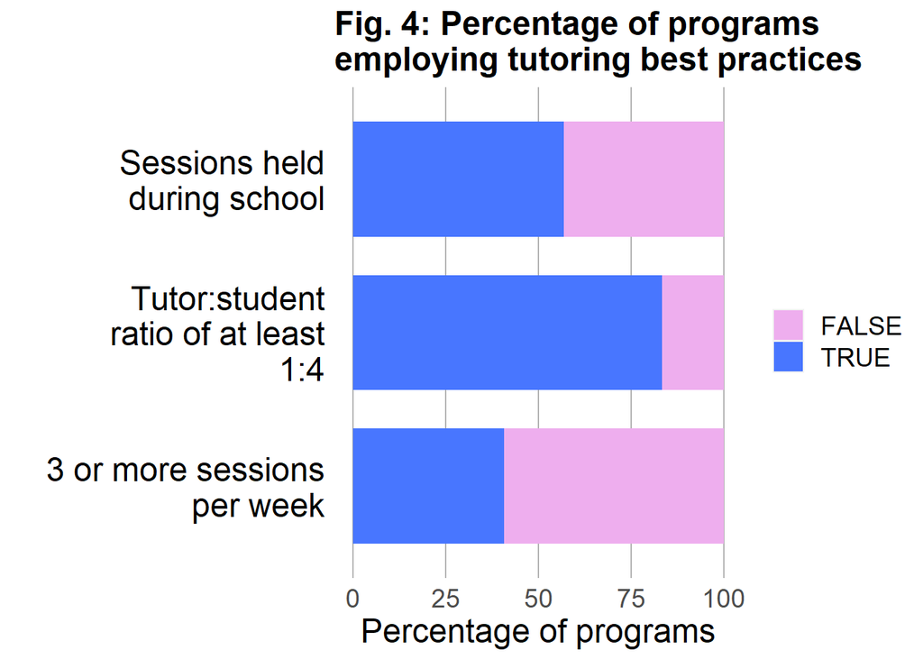

```r
nssa2 %>%
  select(freq, setting, ratio) %>%

  # We need to get frequency, setting, and ratio (3 HIT criteria) into one variable for graphing

  pivot_longer(c(freq, setting, ratio)) %>%

  # Clean the NA values out of the setting variable, and round up to give programs the benefit of the doubt

  mutate(value = as.logical(ceiling(value))) %>%
  filter(!is.na(value)) %>%
  group_by(name) %>%
  mutate(tot = n()) %>%
  ungroup() %>%
  group_by(name, value) %>%
  summarize(prop = n()/tot * 100) %>%

  # For some reason there are many duplicate rows when I try to use an unretained variable in summarize()

  unique() %>%

  # Actual graph

  ggplot(aes(name, prop)) +
  geom_bar(aes(fill = value), stat = "identity", width = 0.75) +

  # Aesthetics for final presentation

  xlab("") +
  ylab("Percentage of programs") +
  scale_fill_manual(values = c("plum2", "royalblue1")) +
  scale_x_discrete(labels = str_wrap(c("3 or more sessions per week",
                                       "Tutor:student ratio of at least 1:4",
                                       "Sessions held during school"),
                                     width = 18)) +
  scale_y_continuous(limits = c(0, 100)) +
  coord_flip() +
  theme(panel.grid.major.y = element_blank(),
        panel.grid.major.x = element_line(color = "gray70"),
        panel.background = element_blank(),
        text = element_text(size = 18),
        plot.title = element_text(size = 18, face = "bold"),
        legend.title = element_blank(),
        axis.ticks.x = element_blank(),
        axis.ticks.y = element_blank(),
        axis.text.y = element_text(size = 18, color = "black")) +

  # Possible captions: "U.S. tutoring programs\nare not organized for best\nstudent outcomes"
                    # "How organizations measure up to recommendations for high-impact tutoring"
                    # "Percentage of organizations fulfilling independent recommendations for high-impact tutoring"
                    #

  ggtitle("Fig. 4: Percentage of programs\nemploying tutoring best practices")
```

If your program is high-quality, are you more likely to have been evaluated in an RCT?

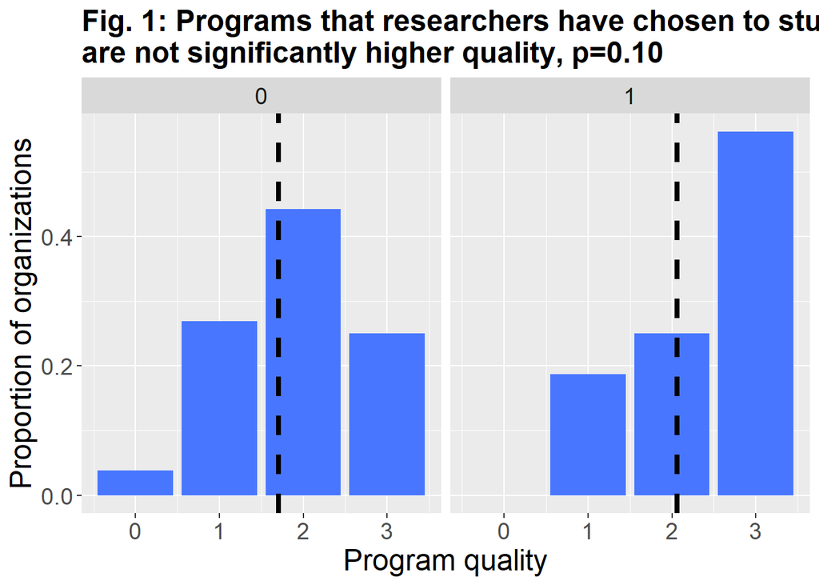

```r
vlines <- nssa2 %>%
  filter(rct != "") %>%
  mutate(eval = factor(rct, levels = unique(rct), labels = c("Not studied", "Studied"))) %>%
  group_by(rct) %>%
  summarize(avg = mean(comp))

nssa2 %>%
  filter(rct != "") %>%
  mutate(eval = factor(rct, levels = unique(rct), labels = c("Not studied", "Studied")),
         comp = ceiling(comp)) %>%
  ggplot(aes(comp, ..prop..)) +
  geom_bar(fill = "royalblue1") +
  facet_wrap(~rct) +
  geom_vline(data = vlines, aes(xintercept = avg), linetype = "dashed", size = 1.5) +
  xlab("Program quality") +
  ylab("Proportion of organizations") +
  theme(text = element_text(size = 18),
        plot.title = element_text(size = 18, face = "bold")) +
  ggtitle("Fig. 1: Programs that researchers have chosen to study\nare not significantly higher quality, p=0.10")
```

```r
t.test(nssa2$comp[nssa$rct == "Yes"], mu = 1.70)
```

```
##
##  One Sample t-test
##
## data:  nssa2$comp[nssa$rct == "Yes"]
## t = 1.7383, df = 15, p-value = 0.1026
## alternative hypothesis: true mean is not equal to 1.7
## 95 percent confidence interval:
##  1.618004 2.506996
## sample estimates:
## mean of x
##    2.0625
```

What about either RCT or QED?

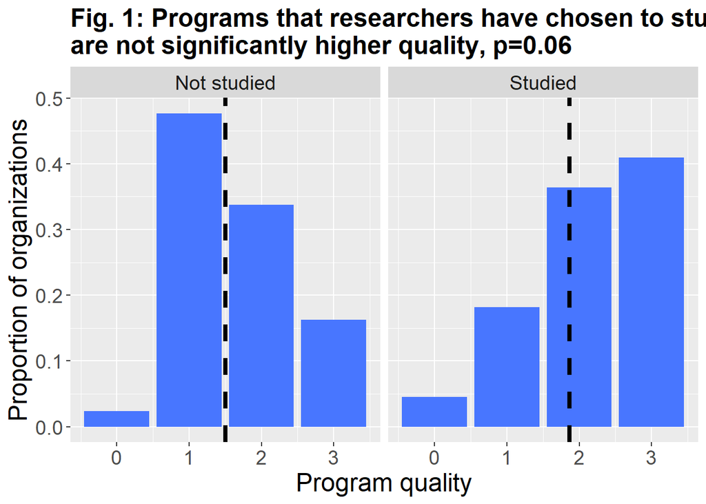

```r
vlines <- nssa2 %>%
  filter(!is.na(eval)) %>%
  mutate(eval = factor(eval, levels = unique(eval), labels = c("Not studied", "Studied"))) %>%
  group_by(eval) %>%
  summarize(avg = mean(comp))

nssa2 %>%
  filter(!is.na(eval)) %>%
  mutate(eval = factor(eval, levels = unique(eval), labels = c("Not studied", "Studied")),
         comp = ceiling(comp)) %>%
  ggplot(aes(comp, ..prop..)) +
  geom_bar(fill = "royalblue1") +
  facet_wrap(~eval) +
  geom_vline(data = vlines, aes(xintercept = avg), linetype = "dashed", size = 1.5) +
  xlab("Program quality") +
  ylab("Proportion of organizations") +
  theme(text = element_text(size = 18),
        plot.title = element_text(size = 18, face = "bold")) +
  ggtitle("Fig. 1: Programs that researchers have chosen to study\nare not significantly higher quality, p=0.06")
```

```r
t.test(nssa2$comp[nssa2$eval == 1], mu = 1.5)
```

```
##
##  One Sample t-test
##
## data:  nssa2$comp[nssa2$eval == 1]
## t = 1.9795, df = 21, p-value = 0.06102
## alternative hypothesis: true mean is not equal to 1.5
## 95 percent confidence interval:
##  1.481606 2.245666
## sample estimates:
## mean of x
##  1.863636
```

What is the effect size of the RCTs?

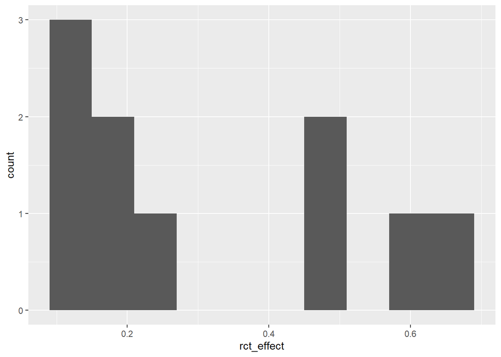

```r
nssa2 %>%
  ggplot(aes(rct_effect)) +
  geom_histogram(bins = 10)
```

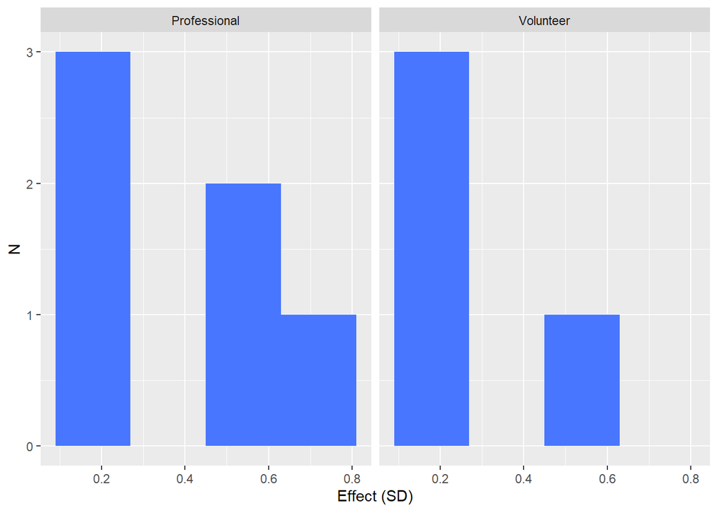

```r
nssa2 %>%
  mutate(pro = factor(pro, levels = c(TRUE, FALSE), labels = c("Professional", "Volunteer")),
         effect = ) %>%
  ggplot(aes(rct_effect)) +
  geom_histogram(bins = 4, fill = "royalblue1") +
  facet_grid(~pro) +
  xlab("Effect (SD)") +
  ylab("N")
```

```r
nssa2 %>%
  select(rct_effect, pro) %>%
  filter(rct_effect != "")
```

```
##    rct_effect   pro
## 1       0.600 FALSE
## 2       0.470  TRUE
## 3       0.120 FALSE
## 4       0.122  TRUE
## 5       0.200  TRUE
## 6       0.640  TRUE
## 7       0.240  TRUE
## 8       0.170 FALSE
## 9       0.100 FALSE
## 10      0.510  TRUE
```

If your program is mostly volunteer-based, are you less likely to be evaluated? Conversely, if your program is professionally run, are you more likely to be evaluated?

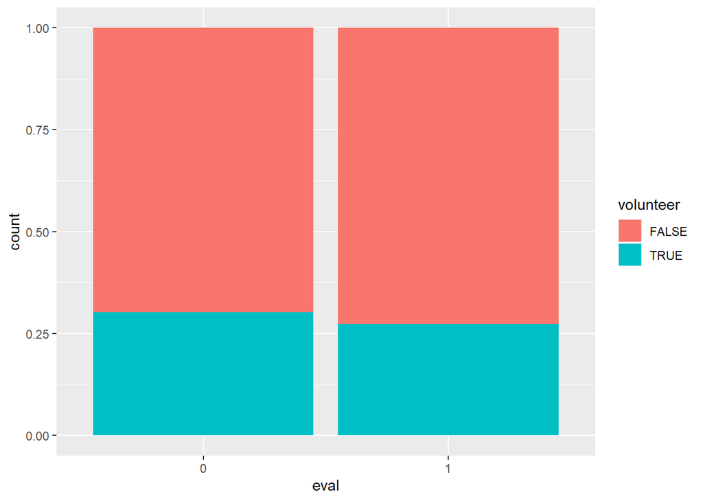

```r
nssa2 %>%
  ggplot(aes(eval)) +
  geom_bar(aes(fill = volunteer), position = "fill")
```

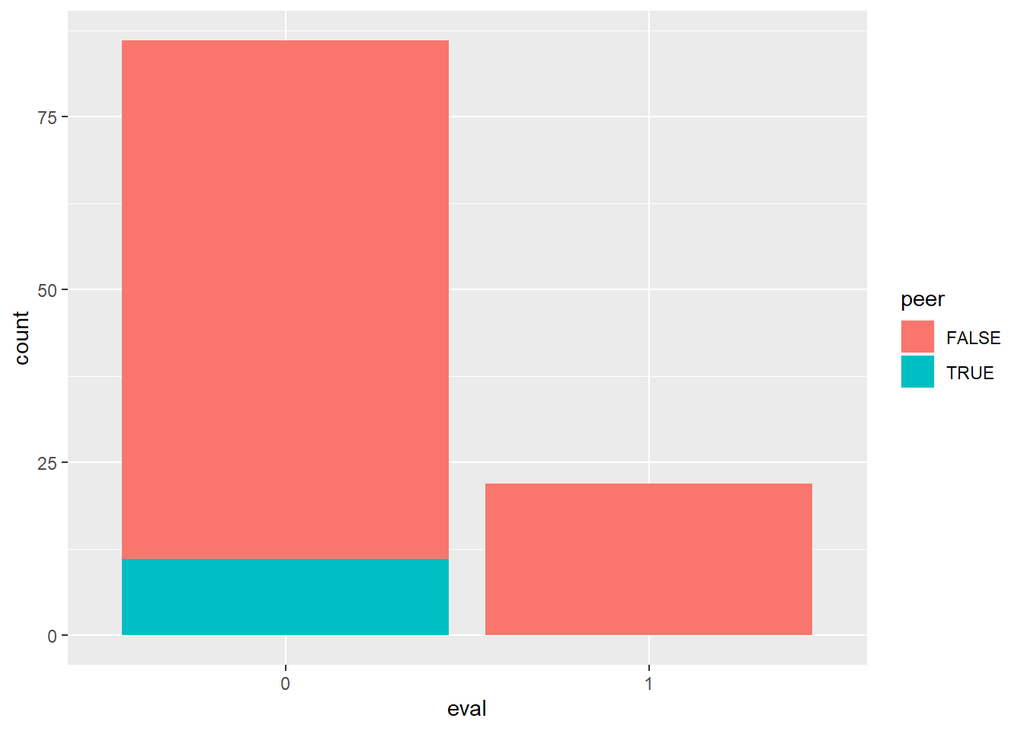

```r
nssa2 %>%
  ggplot(aes(eval)) +
  geom_bar(aes(fill = peer))
```

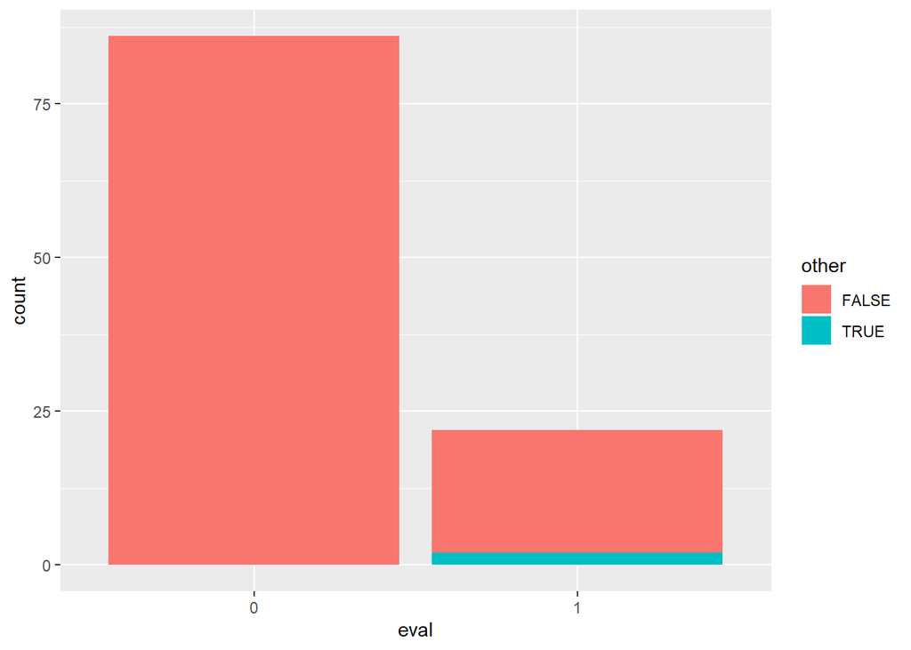

```r
nssa2 %>%
  ggplot(aes(eval)) +
  geom_bar(aes(fill = other))
```

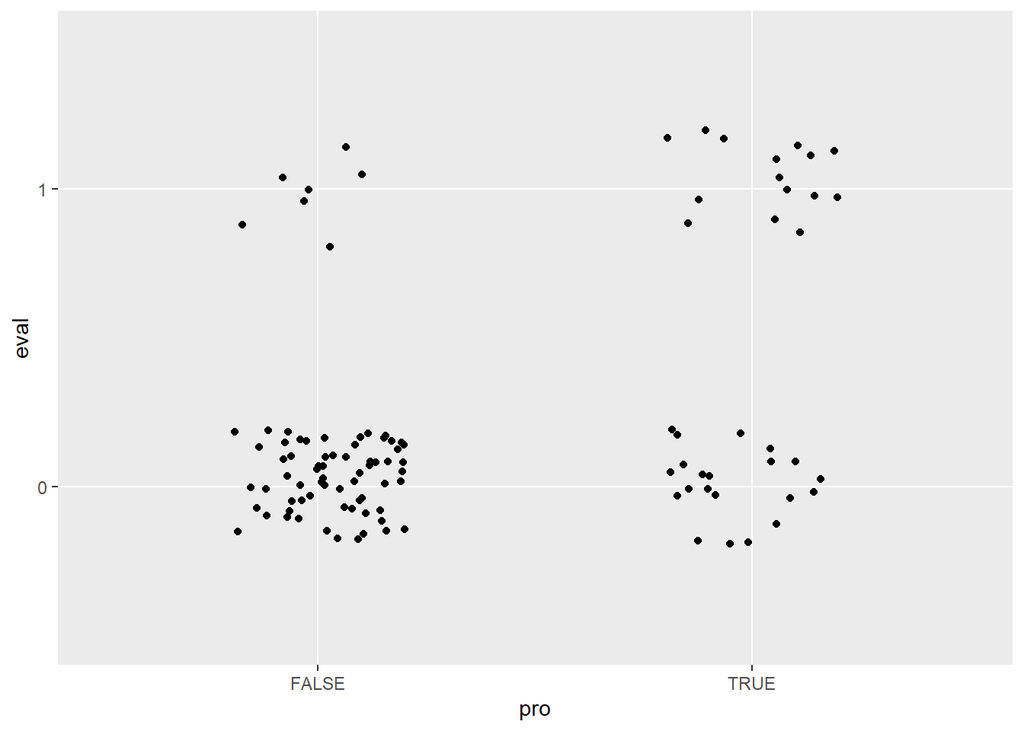

```r
nssa2 %>%
  ggplot(aes(pro, eval)) +
  geom_jitter(width = 0.2, height = 0.2)
```

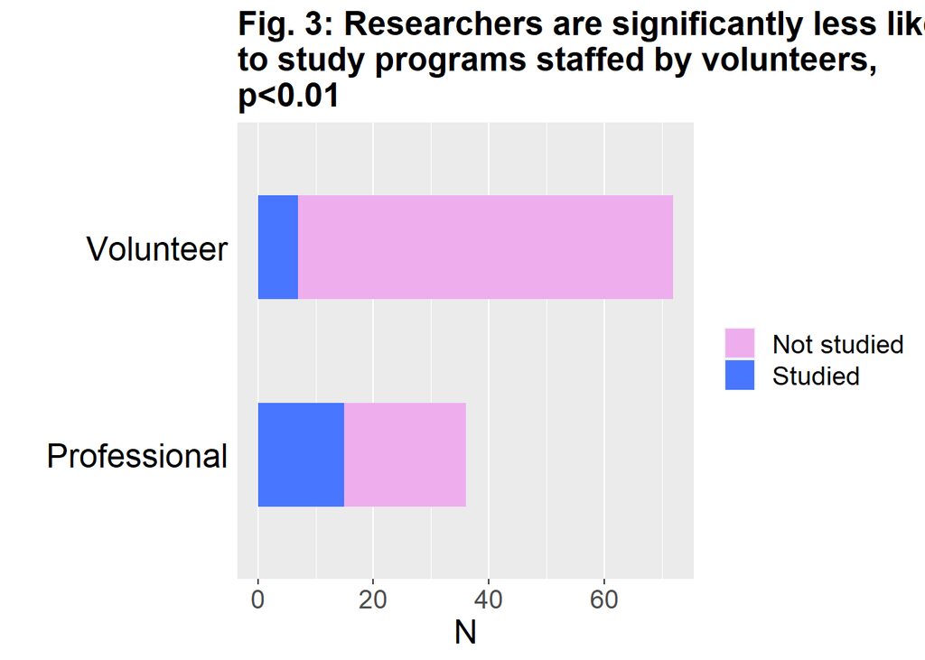

```r
nssa2 %>%
  mutate(pro = factor(pro, levels = c(TRUE, FALSE), labels = c("Professional", "Volunteer")),
         eval = factor(eval, levels = c(0, 1), labels = c("Not studied", "Studied"))) %>%
  ggplot(aes(pro)) +
  geom_bar(aes(fill = eval), width = 0.5) +
  coord_flip() +
  xlab("") +
  ylab("N") +
  theme(text = element_text(size = 18),
        plot.title = element_text(size = 18, face = "bold"),
        legend.title = element_blank(),
        panel.grid.major.y = element_blank(),
        axis.ticks.y = element_blank(),
        axis.text.y = element_text(color = "black", size = 18)) +
  scale_fill_manual(values = c("plum2", "royalblue1")) +
  ggtitle("Fig. 3: Researchers are significantly less likely\nto study programs staffed by volunteers,\np<0.01")
```

```r
chisq.test(table(nssa2$pro, nssa2$eval))
```

```
##
##  Pearson's Chi-squared test with Yates' continuity correction
##
## data:  table(nssa2$pro, nssa2$eval)
## X-squared = 13.193, df = 1, p-value = 0.000281
```

Do volunteer-staffed programs meet HIT criteria?

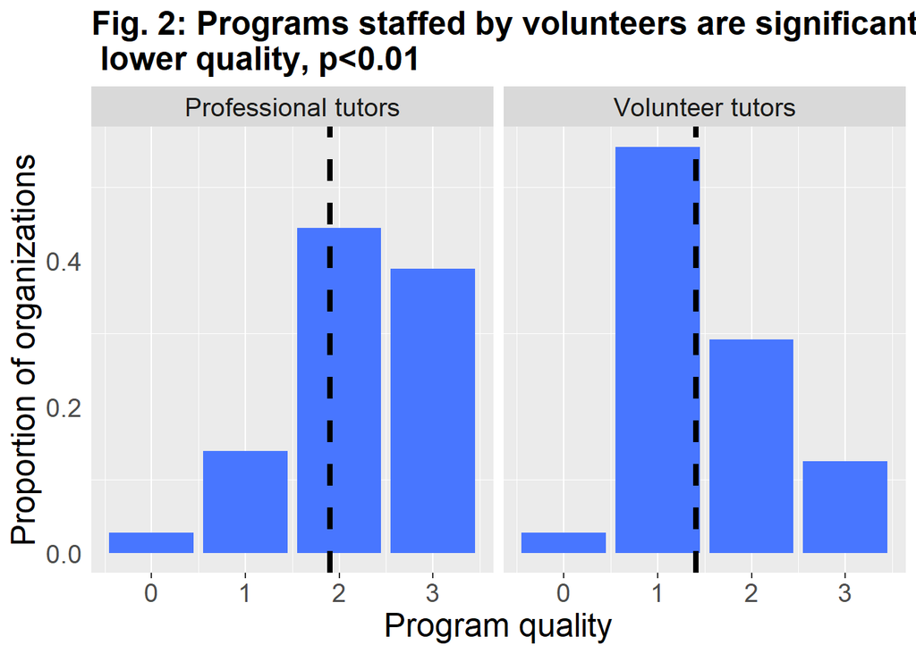

```r
vlines <- nssa2 %>%
  mutate(pro = factor(pro, levels = c(TRUE, FALSE), labels = c("Professional tutors", "Volunteer tutors"))) %>%
  group_by(pro) %>%
  summarize(avg = mean(comp))

nssa2 %>%
  mutate(pro = factor(pro, levels = c(TRUE, FALSE), labels = c("Professional tutors", "Volunteer tutors")),
         comp = ceiling(comp)) %>%
  ggplot(aes(comp, ..prop..)) +
  geom_bar(fill = "royalblue1") +
  facet_grid(~pro) +
  geom_vline(data = vlines, aes(xintercept = avg), linetype = "dashed", size = 1.5) +
  xlab("Program quality") +
  ylab("Proportion of organizations") +
  theme(text = element_text(size = 18),
        plot.title = element_text(size = 18, face = "bold"),
        legend.title = element_blank(),
        panel.grid.major.y = element_blank(),
        axis.ticks.y = element_blank()) +
  ggtitle("Fig. 2: Programs staffed by volunteers are significantly\n lower quality, p<0.01")
```

```r
t.test(nssa2$comp[nssa2$pro == TRUE], mu = 1.41)
```

```
##
##  One Sample t-test
##
## data:  nssa2$comp[nssa2$pro == TRUE]
## t = 4.2537, df = 35, p-value = 0.0001489
## alternative hypothesis: true mean is not equal to 1.41
## 95 percent confidence interval:
##  1.667597 2.137959
## sample estimates:
## mean of x
##  1.902778
```

### Location

I also want to check that the sample of organizations is at least relatively representative. I wanted to make a map, but it looks like I’ll need to finagle with the data before being able to map anything, due to the odd collection format.

Now we can actually start plotting.

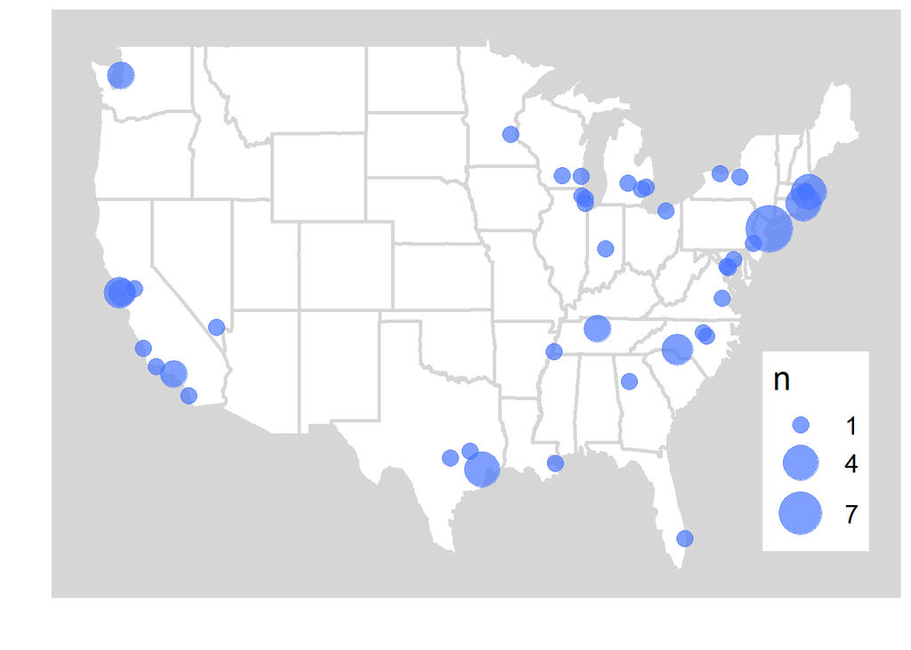

```r
state <- map_data("state")

ggplot() +
  geom_polygon(data = state, aes(long, lat, group = group), fill = "white", color = "#d6d6d6", size = 1) +
  geom_count(aes(nssa3$long[!is.na(nssa3$long)], nssa3$lat[!is.na(nssa3$lat)]), alpha = 0.7, color = "royalblue1") +
  scale_size_continuous(range = c(4, 12), breaks = seq(1, 12, by = 3)) +
  xlab("") +
  ylab("") +
  theme(text = element_text(size = 18),
        panel.grid.major = element_blank(), panel.grid.minor = element_blank(),
        panel.background = element_rect(fill = "#d6d6d6"),
        axis.line = element_line(color = "white"),
        axis.ticks = element_blank(),
        axis.text.x = element_blank(),
        axis.text.y = element_blank(),
        legend.key = element_blank(),
        legend.position = c(0.9, 0.25)) +
  labs(size = "n")
```

```r
ops <- str_split(nssa2$op_location, ", ") %>%
  unlist() %>%
  tolower()

ops <- data.frame(ops) %>%
  mutate(region = ops) %>%
  group_by(region) %>%
  summarize(n = n())

state <- left_join(state, ops)
```

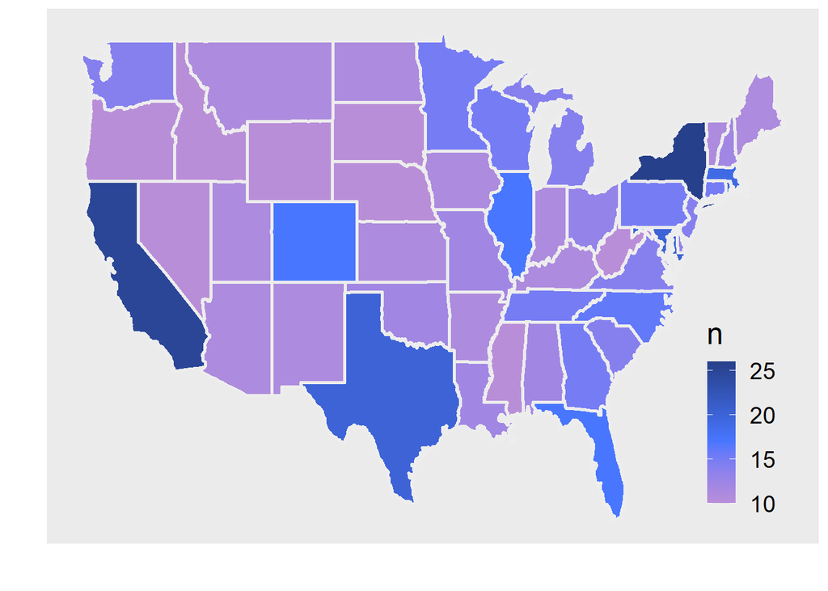

```r
ggplot() +
  geom_polygon(data = state, aes(long, lat, group = group, fill = n), color = "grey93", size = 1) +
  scale_fill_gradient2(low = "plum3",
                       mid = "royalblue1",
                       high = "royalblue4",
                       midpoint = 17) +
  xlab("") +
  ylab("") +
  theme(text = element_text(size = 18),
        panel.grid.major = element_blank(), panel.grid.minor = element_blank(),
        axis.line = element_line(color = "white"),
        axis.ticks = element_blank(),
        axis.text.x = element_blank(),
        axis.text.y = element_blank(),
        legend.key = element_blank(),
        legend.background = element_blank(),
        legend.position = c(0.9, 0.25)) +
  labs(size = "n")
```

Map organizations against population per state.

Also, don’t forget Alaska and Hawaii.

Try to look at location disaggregated by staffing and best practices. Virtual organizations too.

Try analyses again, but omitting virtual organizations.

See whether virtual organizations have been researched.